# SR_02_RLTD_ORG_ADDR_L1

Related organization street address line 1 · Text report

## Overview

**Description**

Address Foreign - AddressLine1

**Table**

`SR-P02-T01-ID-RLTD-TAX-EXEMPED-ORGS` (many)

**Location code**

`SCHED-R-PART-02-COL-A`

**Family**

`SCHED-R-PART-02-COL-A` · siblings: SR_02_RLTD_ORG_ADDR_CITY, SR_02_RLTD_ORG_ADDR_CNTR, SR_02_RLTD_ORG_ADDR_L2, SR_02_RLTD_ORG_ADDR_STATE, SR_02_RLTD_ORG_ADDR_ZIP, SR_02_RLTD_ORG_EIN

**Data type**

text (xsd: StreetAddressType)

**Scope**

PC

**Status**

unreviewed

6

xpaths mapped (6 observed)

846,017

filings with a value

2009–2024

tax years observed

3

open flags (1 errors)

## Flags

| Severity | Flag | Xpath | Detail |
| --- | --- | --- | --- |
| ⚠ error | `COLLISION` | IRS990ScheduleR/IdRelatedTaxExemptOrgGrp/ForeignAddress/AddressLine1Txt | 7037 filings contain 2+ of its xpaths; most common set: /Return/ReturnData/IRS990ScheduleR/IdRelatedTaxExemptOrgGrp/ForeignAddress/AddressLine1Txt ; /Return/ReturnData/IRS990ScheduleR/IdRelatedTaxExem… |
| ⓘ info | `MANY_NOT_REPEATING` | IRS990ScheduleR/IdRelatedTaxExemptOrgGrp/USAddress/AddressLine1Txt | many-to-one table, but 52% of values sit in no repeating element |
| ⓘ info | `MANY_NOT_REPEATING` | IRS990ScheduleR/IdRelatedTaxExemptOrgGrp/USAddress/AddressLine1 | many-to-one table, but 50% of values sit in no repeating element |

## Xpaths

All mapped xpaths (under /Return/ReturnData or /Return/ReturnHeader), oldest first. Charts label each series by its xpath.

| Xpath | Form | Chart label | First year | Last year | Versions | Filings | Repeats in |
| --- | --- | --- | --- | --- | --- | --- | --- |
| IRS990ScheduleR/Form990ScheduleRPartII/AddressUS/AddressLine1 | Sched R | …90ScheduleR/Form990ScheduleRPartII/AddressUS/AddressLine1 | 2009 | 2012 | 18 | 132,312 | 51.3% |
| IRS990ScheduleR/Form990ScheduleRPartII/AddressForeign/AddressLine1 | Sched R | …eduleR/Form990ScheduleRPartII/AddressForeign/AddressLine1 | 2009 | 2012 | 15 | 1,682 | 31.0% |
| IRS990ScheduleR/IdRelatedTaxExemptOrgGrp/USAddress/AddressLine1 | Sched R | …ScheduleR/IdRelatedTaxExemptOrgGrp/USAddress/AddressLine1 | 2013 | 2013 | 3 | 47,596 | 49.2% |
| IRS990ScheduleR/IdRelatedTaxExemptOrgGrp/ForeignAddress/AddressLine1 | Sched R | …uleR/IdRelatedTaxExemptOrgGrp/ForeignAddress/AddressLine1 | 2013 | 2013 | 3 | 683 | 30.0% |
| IRS990ScheduleR/IdRelatedTaxExemptOrgGrp/USAddress/AddressLine1Txt | Sched R | …eduleR/IdRelatedTaxExemptOrgGrp/USAddress/AddressLine1Txt | 2014 | 2024 | 34 | 651,290 | 47.9% |
| IRS990ScheduleR/IdRelatedTaxExemptOrgGrp/ForeignAddress/AddressLine1Txt | Sched R | …R/IdRelatedTaxExemptOrgGrp/ForeignAddress/AddressLine1Txt | 2014 | 2024 | 34 | 12,454 | 31.6% |

## Coverage

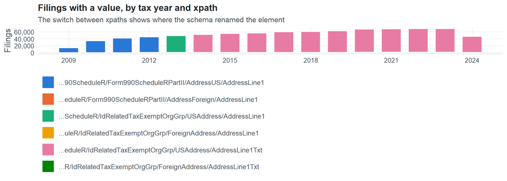

**Table view**

Table view: filings by tax year and series

| Tax year | …90ScheduleR/Form990ScheduleRPartII/AddressUS/AddressLine1 | …eduleR/Form990ScheduleRPartII/AddressForeign/AddressLine1 | …ScheduleR/IdRelatedTaxExemptOrgGrp/USAddress/AddressLine1 | …uleR/IdRelatedTaxExemptOrgGrp/ForeignAddress/AddressLine1 | …eduleR/IdRelatedTaxExemptOrgGrp/USAddress/AddressLine1Txt | …R/IdRelatedTaxExemptOrgGrp/ForeignAddress/AddressLine1Txt |
| --- | --- | --- | --- | --- | --- | --- |
| 2009 | 13,294 | 158 | 0 | 0 | 0 | 0 |
| 2010 | 33,609 | 405 | 0 | 0 | 0 | 0 |
| 2011 | 40,919 | 521 | 0 | 0 | 0 | 0 |
| 2012 | 44,490 | 598 | 0 | 0 | 0 | 0 |
| 2013 | 0 | 0 | 47,596 | 683 | 0 | 0 |
| 2014 | 0 | 0 | 0 | 0 | 51,116 | 775 |
| 2015 | 0 | 0 | 0 | 0 | 53,523 | 857 |
| 2016 | 0 | 0 | 0 | 0 | 55,448 | 908 |
| 2017 | 0 | 0 | 0 | 0 | 58,874 | 1,039 |
| 2018 | 0 | 0 | 0 | 0 | 59,172 | 1,134 |
| 2019 | 0 | 0 | 0 | 0 | 60,848 | 1,205 |
| 2020 | 0 | 0 | 0 | 0 | 65,651 | 1,342 |
| 2021 | 0 | 0 | 0 | 0 | 66,652 | 1,371 |
| 2022 | 0 | 0 | 0 | 0 | 67,472 | 1,429 |
| 2023 | 0 | 0 | 0 | 0 | 67,375 | 1,447 |
| 2024 | 0 | 0 | 0 | 0 | 45,159 | 947 |

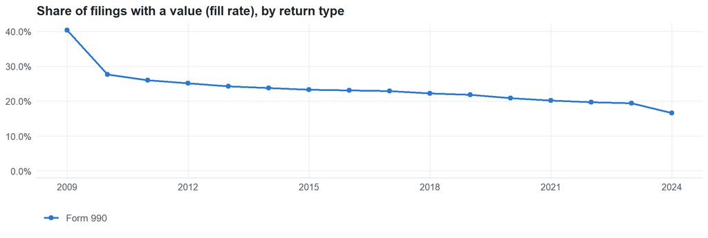

**Table view**

Table view: fill rate

| Tax year | Return type | Filings | All filings | Fill rate |
| --- | --- | --- | --- | --- |
| 2009 | Form 990 | 13,452 | 33,311 | 40.38% |
| 2010 | Form 990 | 34,014 | 123,025 | 27.65% |
| 2011 | Form 990 | 41,440 | 159,504 | 25.98% |
| 2012 | Form 990 | 45,088 | 179,688 | 25.09% |
| 2013 | Form 990 | 48,279 | 198,855 | 24.28% |
| 2014 | Form 990 | 51,891 | 218,619 | 23.74% |
| 2015 | Form 990 | 54,380 | 233,519 | 23.29% |
| 2016 | Form 990 | 56,356 | 243,903 | 23.11% |
| 2017 | Form 990 | 59,913 | 261,612 | 22.90% |
| 2018 | Form 990 | 60,306 | 271,442 | 22.22% |
| 2019 | Form 990 | 62,053 | 283,694 | 21.87% |
| 2020 | Form 990 | 66,993 | 320,342 | 20.91% |
| 2021 | Form 990 | 68,023 | 336,480 | 20.22% |
| 2022 | Form 990 | 68,901 | 349,055 | 19.74% |
| 2023 | Form 990 | 68,822 | 354,768 | 19.40% |
| 2024 | Form 990 | 46,106 | 277,298 | 16.63% |

## Repeating groups

Table cardinality in the concordance: **many**. 6 of 6 observed xpaths repeat within a filing.

Repeating element each xpath was observed in (from the raw indexed xpath)

| Xpath | Repeating element | Filings (summed over years) |
| --- | --- | --- |
| IRS990ScheduleR/Form990ScheduleRPartII/AddressForeign/AddressLine1 | (none) | 587 |
| IRS990ScheduleR/Form990ScheduleRPartII/AddressForeign/AddressLine1 | IRS990ScheduleR/Form990ScheduleRPartII | 1095 |
| IRS990ScheduleR/Form990ScheduleRPartII/AddressUS/AddressLine1 | (none) | 64031 |
| IRS990ScheduleR/Form990ScheduleRPartII/AddressUS/AddressLine1 | IRS990ScheduleR/Form990ScheduleRPartII | 68281 |
| IRS990ScheduleR/IdRelatedTaxExemptOrgGrp/ForeignAddress/AddressLine1 | (none) | 257 |
| IRS990ScheduleR/IdRelatedTaxExemptOrgGrp/ForeignAddress/AddressLine1 | IRS990ScheduleR/IdRelatedTaxExemptOrgGrp | 426 |
| IRS990ScheduleR/IdRelatedTaxExemptOrgGrp/USAddress/AddressLine1 | (none) | 23966 |
| IRS990ScheduleR/IdRelatedTaxExemptOrgGrp/USAddress/AddressLine1 | IRS990ScheduleR/IdRelatedTaxExemptOrgGrp | 23630 |
| IRS990ScheduleR/IdRelatedTaxExemptOrgGrp/ForeignAddress/AddressLine1Txt | (none) | 5068 |
| IRS990ScheduleR/IdRelatedTaxExemptOrgGrp/ForeignAddress/AddressLine1Txt | IRS990ScheduleR/IdRelatedTaxExemptOrgGrp | 7386 |
| IRS990ScheduleR/IdRelatedTaxExemptOrgGrp/USAddress/AddressLine1Txt | (none) | 336644 |
| IRS990ScheduleR/IdRelatedTaxExemptOrgGrp/USAddress/AddressLine1Txt | IRS990ScheduleR/IdRelatedTaxExemptOrgGrp | 314646 |

## Values

| Result | Check | Detail |
| --- | --- | --- |
| ✓ pass | Values are text, not numbers | 0% of values are numeric |
| ⓘ info | No sign of truncation | …eduleR/Form990ScheduleRPartII/AddressForeign/AddressLine1: longest value is exactly 35 characters; …90ScheduleR/Form990ScheduleRPartII/AddressUS/AddressLine1: longest value is exactly 35 characters; … |
| ✓ pass | No dominant boilerplate value | most common value covers 7% of filings: “60486 FRANKFURT AM MAIN” |

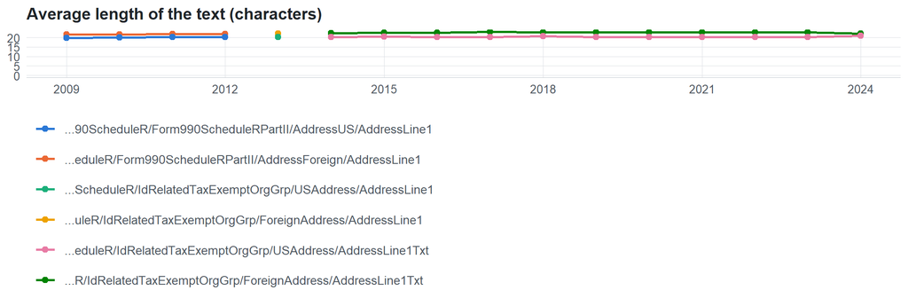

**Table view**

Table view: length and variety by tax year

| Series | Tax year | Filings | Avg length | Max length | Distinct values (approx.) |
| --- | --- | --- | --- | --- | --- |
| …90ScheduleR/Form990ScheduleRPartII/AddressUS/AddressLine1 | 2009 | 13,294 | 20 | 35 | 11,448 |
| …90ScheduleR/Form990ScheduleRPartII/AddressUS/AddressLine1 | 2010 | 33,609 | 20 | 35 | 20,792 |
| …90ScheduleR/Form990ScheduleRPartII/AddressUS/AddressLine1 | 2011 | 40,919 | 20 | 35 | 31,640 |
| …90ScheduleR/Form990ScheduleRPartII/AddressUS/AddressLine1 | 2012 | 44,490 | 20 | 35 | 32,181 |
| …eduleR/Form990ScheduleRPartII/AddressForeign/AddressLine1 | 2009 | 158 | 22 | 35 | 184 |
| …eduleR/Form990ScheduleRPartII/AddressForeign/AddressLine1 | 2010 | 405 | 22 | 35 | 383 |
| …eduleR/Form990ScheduleRPartII/AddressForeign/AddressLine1 | 2011 | 521 | 22 | 35 | 414 |
| …eduleR/Form990ScheduleRPartII/AddressForeign/AddressLine1 | 2012 | 598 | 22 | 35 | 524 |
| …ScheduleR/IdRelatedTaxExemptOrgGrp/USAddress/AddressLine1 | 2013 | 47,596 | 20 | 35 | 19,670 |
| …uleR/IdRelatedTaxExemptOrgGrp/ForeignAddress/AddressLine1 | 2013 | 683 | 22 | 35 | 498 |
| …eduleR/IdRelatedTaxExemptOrgGrp/USAddress/AddressLine1Txt | 2014 | 51,116 | 20 | 35 | 28,227 |
| …eduleR/IdRelatedTaxExemptOrgGrp/USAddress/AddressLine1Txt | 2015 | 53,523 | 20 | 35 | 25,187 |
| …eduleR/IdRelatedTaxExemptOrgGrp/USAddress/AddressLine1Txt | 2016 | 55,448 | 20 | 35 | 48,214 |
| …eduleR/IdRelatedTaxExemptOrgGrp/USAddress/AddressLine1Txt | 2017 | 58,874 | 20 | 35 | 40,937 |
| …eduleR/IdRelatedTaxExemptOrgGrp/USAddress/AddressLine1Txt | 2018 | 59,172 | 21 | 35 | 48,773 |
| …eduleR/IdRelatedTaxExemptOrgGrp/USAddress/AddressLine1Txt | 2019 | 60,848 | 20 | 35 | 27,829 |
| …eduleR/IdRelatedTaxExemptOrgGrp/USAddress/AddressLine1Txt | 2020 | 65,651 | 20 | 35 | 27,219 |
| …eduleR/IdRelatedTaxExemptOrgGrp/USAddress/AddressLine1Txt | 2021 | 66,652 | 20 | 35 | 47,460 |
| …eduleR/IdRelatedTaxExemptOrgGrp/USAddress/AddressLine1Txt | 2022 | 67,472 | 20 | 35 | 70,413 |
| …eduleR/IdRelatedTaxExemptOrgGrp/USAddress/AddressLine1Txt | 2023 | 67,375 | 20 | 35 | 35,245 |
| …eduleR/IdRelatedTaxExemptOrgGrp/USAddress/AddressLine1Txt | 2024 | 45,159 | 21 | 35 | 22,770 |
| …R/IdRelatedTaxExemptOrgGrp/ForeignAddress/AddressLine1Txt | 2014 | 775 | 22 | 35 | 603 |
| …R/IdRelatedTaxExemptOrgGrp/ForeignAddress/AddressLine1Txt | 2015 | 857 | 23 | 35 | 675 |
| …R/IdRelatedTaxExemptOrgGrp/ForeignAddress/AddressLine1Txt | 2016 | 908 | 23 | 35 | 908 |
| …R/IdRelatedTaxExemptOrgGrp/ForeignAddress/AddressLine1Txt | 2017 | 1,039 | 23 | 35 | 1,153 |
| …R/IdRelatedTaxExemptOrgGrp/ForeignAddress/AddressLine1Txt | 2018 | 1,134 | 23 | 35 | 1,383 |
| …R/IdRelatedTaxExemptOrgGrp/ForeignAddress/AddressLine1Txt | 2019 | 1,205 | 23 | 35 | 968 |
| …R/IdRelatedTaxExemptOrgGrp/ForeignAddress/AddressLine1Txt | 2020 | 1,342 | 23 | 35 | 1,039 |
| …R/IdRelatedTaxExemptOrgGrp/ForeignAddress/AddressLine1Txt | 2021 | 1,371 | 23 | 35 | 1,454 |
| …R/IdRelatedTaxExemptOrgGrp/ForeignAddress/AddressLine1Txt | 2022 | 1,429 | 23 | 35 | 1,934 |
| …R/IdRelatedTaxExemptOrgGrp/ForeignAddress/AddressLine1Txt | 2023 | 1,447 | 23 | 35 | 1,149 |
| …R/IdRelatedTaxExemptOrgGrp/ForeignAddress/AddressLine1Txt | 2024 | 947 | 22 | 35 | 928 |

Most common values by xpath (all years; long values truncated)

| Series | Value | Filings | Share |
| --- | --- | --- | --- |
| …90ScheduleR/Form990ScheduleRPartII/AddressUS/AddressLine1 | PO Box 45998 | 418 | 0.3% |
| …90ScheduleR/Form990ScheduleRPartII/AddressUS/AddressLine1 | 101 S COLUMBIA STREET | 396 | 0.3% |
| …90ScheduleR/Form990ScheduleRPartII/AddressUS/AddressLine1 | 4100 SUNNY ISLE CHRISTIANSTED | 396 | 0.3% |
| …90ScheduleR/Form990ScheduleRPartII/AddressUS/AddressLine1 | 5411 HOLLYWOOD BLVD | 396 | 0.3% |
| …90ScheduleR/Form990ScheduleRPartII/AddressUS/AddressLine1 | 351 SW 9TH STREET | 362 | 0.3% |
| …90ScheduleR/Form990ScheduleRPartII/AddressUS/AddressLine1 | 1111 6TH AVENUE | 189 | 0.1% |
| …90ScheduleR/Form990ScheduleRPartII/AddressUS/AddressLine1 | PO BOX 517 | 184 | 0.1% |
| …90ScheduleR/Form990ScheduleRPartII/AddressUS/AddressLine1 | 3325 POCAHONTAS ROAD | 174 | 0.1% |
| …90ScheduleR/Form990ScheduleRPartII/AddressUS/AddressLine1 | 2727 McClelland Blvd | 141 | 0.1% |
| …90ScheduleR/Form990ScheduleRPartII/AddressUS/AddressLine1 | 1320 N MONROE STREET | 134 | 0.1% |
| …90ScheduleR/Form990ScheduleRPartII/AddressUS/AddressLine1 | 1660 DUKE STREET | 134 | 0.1% |
| …90ScheduleR/Form990ScheduleRPartII/AddressUS/AddressLine1 | 515 P STREET | 134 | 0.1% |
| …90ScheduleR/Form990ScheduleRPartII/AddressUS/AddressLine1 | 6570 WEST AVENUE L-12 | 133 | 0.1% |
| …90ScheduleR/Form990ScheduleRPartII/AddressUS/AddressLine1 | 711 NUCKOLLS STREET | 133 | 0.1% |
| …90ScheduleR/Form990ScheduleRPartII/AddressUS/AddressLine1 | 904 E MILWAUKEE AVENUE | 133 | 0.1% |
| …90ScheduleR/Form990ScheduleRPartII/AddressUS/AddressLine1 | 911 N STUDEBAKER ROAD | 133 | 0.1% |
| …90ScheduleR/Form990ScheduleRPartII/AddressUS/AddressLine1 | 1011 6TH AVENUE | 129 | 0.1% |
| …90ScheduleR/Form990ScheduleRPartII/AddressUS/AddressLine1 | 122 KICKAPOO STREET | 129 | 0.1% |
| …90ScheduleR/Form990ScheduleRPartII/AddressUS/AddressLine1 | 15211 SHERMAN WAY | 129 | 0.1% |
| …90ScheduleR/Form990ScheduleRPartII/AddressUS/AddressLine1 | 167000 CHATSWORTH STREET | 129 | 0.1% |
| …90ScheduleR/Form990ScheduleRPartII/AddressUS/AddressLine1 | 1919 NORTH 11TH STREET | 129 | 0.1% |
| …90ScheduleR/Form990ScheduleRPartII/AddressUS/AddressLine1 | 607 NORTH HIGHTOWER | 129 | 0.1% |
| …90ScheduleR/Form990ScheduleRPartII/AddressUS/AddressLine1 | PO Box 1990 | 101 | 0.1% |
| …90ScheduleR/Form990ScheduleRPartII/AddressUS/AddressLine1 | 1 St Josephs Drive | 100 | 0.1% |
| …90ScheduleR/Form990ScheduleRPartII/AddressUS/AddressLine1 | 1010 Three Springs Blvd | 100 | 0.1% |
| …90ScheduleR/Form990ScheduleRPartII/AddressUS/AddressLine1 | 1031 East Seventh Street | 100 | 0.1% |
| …90ScheduleR/Form990ScheduleRPartII/AddressUS/AddressLine1 | 1111 6th Avenue | 100 | 0.1% |
| …90ScheduleR/Form990ScheduleRPartII/AddressUS/AddressLine1 | 1301 15th Avenue West | 100 | 0.1% |
| …90ScheduleR/Form990ScheduleRPartII/AddressUS/AddressLine1 | 1314 3rd Avenue | 100 | 0.1% |
| …90ScheduleR/Form990ScheduleRPartII/AddressUS/AddressLine1 | 1450 Battersby Avenue | 100 | 0.1% |

First rows shown.

## Examples

| Tax year | Return | Xpath | Organization | Value | Source |
| --- | --- | --- | --- | --- | --- |
| 2024 | 990 | IRS990ScheduleR/IdRelatedTaxExemptOrgGrp/ForeignAddress/AddressLine1Txt | ACCION INTERNATIONAL | 9/3 KAISER-E-HIND 1 FL RICHMO | [XML](https://gt990datalake-rawdata.s3.amazonaws.com/EfileData/XmlFiles/202503189349301700_public.xml) |
| 2024 | 990 | IRS990ScheduleR/IdRelatedTaxExemptOrgGrp/USAddress/AddressLine1Txt | APPALACHIAN CENTER FOR EXCELLENCE IN | PO BOX 7070 | [XML](https://gt990datalake-rawdata.s3.amazonaws.com/EfileData/XmlFiles/202543119349302369_public.xml) |
| 2023 | 990 | IRS990ScheduleR/IdRelatedTaxExemptOrgGrp/ForeignAddress/AddressLine1Txt | WILDAID INC | 33/F 15 QUEENS ROAD CENTRAL | [XML](https://gt990datalake-rawdata.s3.amazonaws.com/EfileData/XmlFiles/202511349349312851_public.xml) |
| 2023 | 990 | IRS990ScheduleR/IdRelatedTaxExemptOrgGrp/USAddress/AddressLine1Txt | ZEPF CENTER | 6605 W CENTRAL AVE | [XML](https://gt990datalake-rawdata.s3.amazonaws.com/EfileData/XmlFiles/202423399349300887_public.xml) |
| 2022 | 990 | IRS990ScheduleR/IdRelatedTaxExemptOrgGrp/ForeignAddress/AddressLine1Txt | INSURANCE INFORMATION INSTITUTE INC | 18 CHATER ROAD | [XML](https://gt990datalake-rawdata.s3.amazonaws.com/EfileData/XmlFiles/202332649349300223_public.xml) |
| 2022 | 990 | IRS990ScheduleR/IdRelatedTaxExemptOrgGrp/USAddress/AddressLine1Txt | THE GOOD SHEPHERD HOME FOR THE AGED INC | 1105 SCHROCK ROAD STE 100 | [XML](https://gt990datalake-rawdata.s3.amazonaws.com/EfileData/XmlFiles/202401089349300430_public.xml) |
| 2021 | 990 | IRS990ScheduleR/IdRelatedTaxExemptOrgGrp/ForeignAddress/AddressLine1Txt | THE AMERICAN CHAMBER OF COMMERCE | FLOOR 3 GATE 4 PACIFIC CENTURY PL | [XML](https://gt990datalake-rawdata.s3.amazonaws.com/EfileData/XmlFiles/202203199349330955_public.xml) |
| 2021 | 990 | IRS990ScheduleR/IdRelatedTaxExemptOrgGrp/USAddress/AddressLine1Txt | VIRGINIA BEACH PUBLIC SCHOOLS | PO BOX 6038 | [XML](https://gt990datalake-rawdata.s3.amazonaws.com/EfileData/XmlFiles/202310839349300011_public.xml) |
| 2020 | 990 | IRS990ScheduleR/IdRelatedTaxExemptOrgGrp/ForeignAddress/AddressLine1Txt | Oxford University Development (North America) | Wellington Square | [XML](https://gt990datalake-rawdata.s3.amazonaws.com/EfileData/XmlFiles/202201159349301700_public.xml) |
| 2020 | 990 | IRS990ScheduleR/IdRelatedTaxExemptOrgGrp/USAddress/AddressLine1Txt | PLUMBERS & STEAMFITTERS LOC 60 ED TRUST | 3515 I-10 Service Road | [XML](https://gt990datalake-rawdata.s3.amazonaws.com/EfileData/XmlFiles/202201749349301215_public.xml) |
| 2019 | 990 | IRS990ScheduleR/IdRelatedTaxExemptOrgGrp/ForeignAddress/AddressLine1Txt | INNOVATION CENTER FOR ENERGY AND TRANSPORTATION | 1904 E-TOWER C12 GUANGHUA RD | [XML](https://gt990datalake-rawdata.s3.amazonaws.com/EfileData/XmlFiles/202011219349300541_public.xml) |
| 2019 | 990 | IRS990ScheduleR/IdRelatedTaxExemptOrgGrp/USAddress/AddressLine1Txt | INDEPENDENCE IV INC | 770 WOODLANE ROAD SUITE 63 | [XML](https://gt990datalake-rawdata.s3.amazonaws.com/EfileData/XmlFiles/202111349349304201_public.xml) |

## Reviewer checklist

- The definition matches the form line and instructions for every xpath’s schema years.
- Every xpath pooled here measures the same thing on the 990 and 990-EZ (close enough for analysis).
- The coverage chart has no unexplained gaps or jumps between tax years.
- Each open flag is fixed, or accepted with a note in validation_log.csv.
- Values answer the question on the form line (not another line’s explanation).
- Boilerplate such as ‘See Schedule O’ or ‘N/A’ is expected here, or should be treated as missing.
- Text that is really a number or a code is flagged for a different data type.

Record the review as a row in `inst/extdata/src/validation_log.csv` (variable_name, reviewer, date, status, note). Evidence built 2026-09-23 17:09:04 MST from the ef2 DuckDB builds (tax years 2009–2024).